# Case_Study07

## Case Study 07

We are going to be looking at 6 IBC businesses and pick which would be the best one to give a loan based on the data they have provided us. I have taken out a couple of transactions that where recorded in April, since these transactions happened before the companies officially started. There were also some “Missed” rows that where taken out. We are first going to take a look at the companies gross revenue on a daily, weekly, and monthly basis

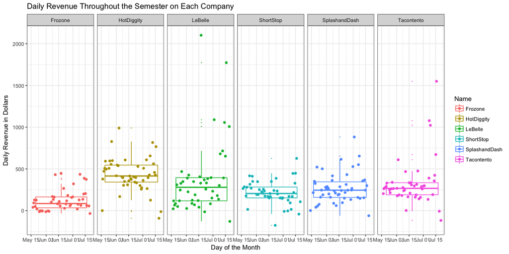

```r
daily %>%
  ggplot(aes(x = daily, y = sales, color = Name)) +
  geom_boxplot(outlier.size = 0) +
  geom_jitter() +
  facet_grid(. ~ Name) +
  labs( x = "Day of the Month",
    y = "Daily Revenue in Dollars",
    title = "Daily Revenue Throughout the Semester on Each Company") +
  theme_bw()
```

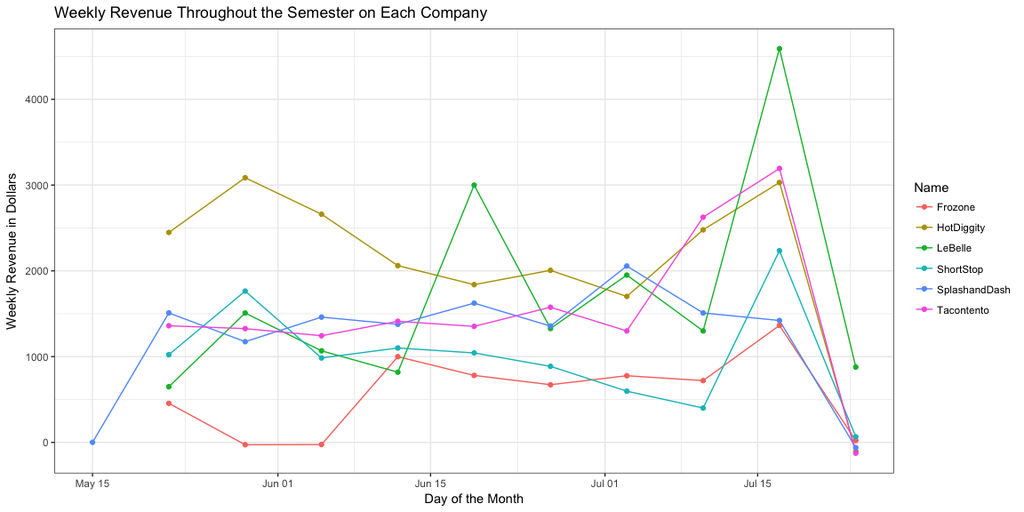

```r
weekly %>%
  ggplot(aes(x = weekly, y = sales, color = Name)) +
  geom_line() +
  geom_point() +
  labs( x = "Day of the Month",
    y = "Weekly Revenue in Dollars",
    title = "Weekly Revenue Throughout the Semester on Each Company") +
  theme_bw()
```

With this plot we can see that HotDiggity was able to make more profit than most companies on most of the weeks. LeBelle seemed to have some high peaks, but also seemed to be the most variable from week to week. It is also interesting to note that on the second to last week that the profits seemed to take a jump on most of the companies. This could be due to more recording error, or they started discounting products so they could make more profit before the end of the semester.

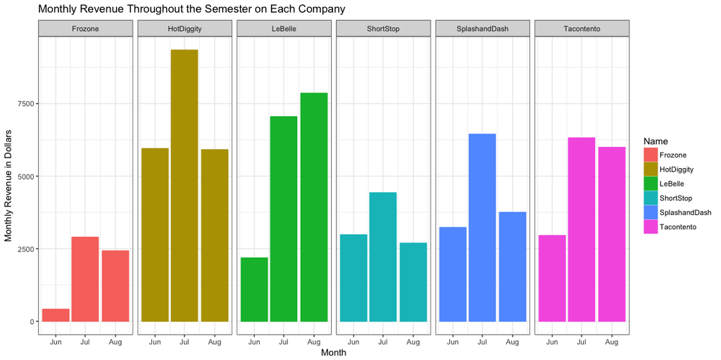

```r
monthly %>%
  ggplot(aes(x = monthly, y = sales, color = Name)) +
  geom_bar(aes(fill = Name), stat = "identity") +
  facet_grid(. ~ Name) +
  labs( x = "Month",
    y = "Monthly Revenue in Dollars",
    title = "Monthly Revenue Throughout the Semester on Each Company") +
  theme_bw()
```

HotDiggity is still looking pretty good even on a monthly basis.

```r
pander(sem[2-3])
```

| Name | sales |
| --- | --- |
| Frozone | 5741 |
| HotDiggity | 21207 |
| LeBelle | 17089 |
| ShortStop | 10101 |
| SplashandDash | 13428 |
| Tacontento | 15264 |

Here is the total gross revenue that each company earned during the course of the semester. HotDiggity had the highest with 21206.72, Lebelle with 17089.30, and Tacontento with 15264.24

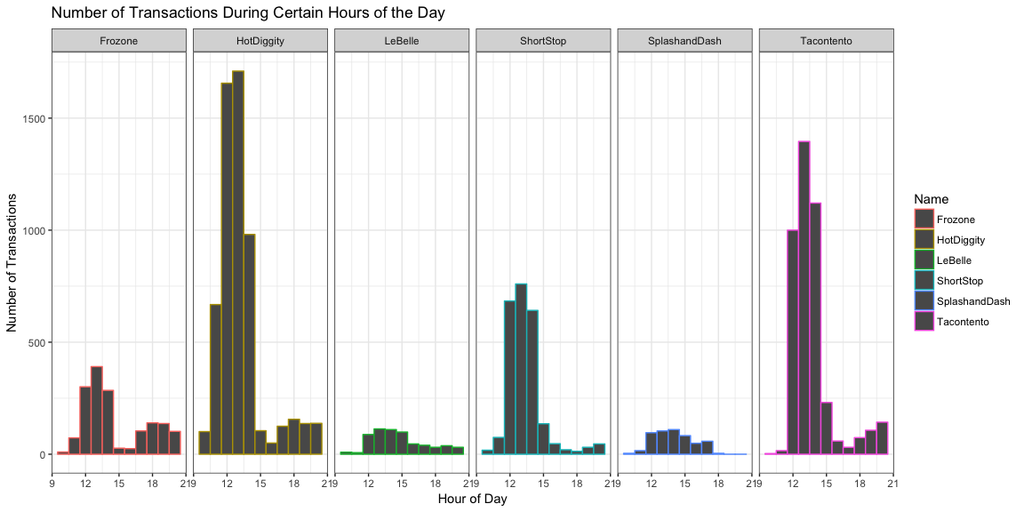

```r
hourly %>%
  ggplot(aes(x = hour, color = Name)) +
  geom_histogram(bins = 11) +
  facet_grid(. ~ Name) +
  labs( x = "Hour of Day",
    y = "Number of Transactions",
    title = "Number of Transactions During Certain Hours of the Day") +
  theme_bw()
```

This plot shows the sale traffic throughout the day. It is only showing the hours between 10 AM - 9 PM. It looks like it is the most busy from 12 - 3. It is interesting to see that even though HotDiggity has the most amount of sales and highest gross revenue, LeBelle has far lower number of sales, but was able to come in second with gross revenue.